title: “DSi and Si:N:P stoich over time” output: html_document: toc: true toc_float: true number_sections: true collapsed: false

# 1 Setup for concentrations + ratios vs time

Read in data and check out how many observations of each variable we have to play with

> For now, treating SRP as PO4! But this is probably wrong

```r
sisyn <- read_csv("20201111_masterdata_RAW.csv")

sisyn <- sisyn %>%
  mutate(variable=ifelse(variable=="SRP", "PO4", variable))

unique(sisyn$variable)
```

```
##  [1] "alkalinity"                  "Benthic.Chl"
##  [3] "Ca"                          "Cl"
##  [5] "DIC"                         "DIN"
##  [7] "DOC"                         "DSi"
##  [9] "Instantaneous.Q.(Discharge)" "K"
## [11] "Mg"                          "Na"
## [13] "NH4"                         "NOx"
## [15] "pH"                          "PO4"
## [17] "SO4"                         "Spec.Cond"
## [19] "Temp.C"                      "TN"
## [21] "TP"                          "Turbidity"
## [23] "Conductivity"                "TDN"
## [25] "TDP"                         "Suspended.Chl"
## [27] "TSS"                         "Daily.Avg.Q.(Discharge)"
## [29] "DON"                         "NO3"
## [31] "TOC"                         "VSS"
```

```r
sisyn %>% count(variable, sort = TRUE) %>% kable()
```

| variable | n |
| --- | --- |
| DSi | 42817 |
| pH | 37587 |
| NOx | 37392 |
| K | 35970 |
| Na | 35931 |
| Mg | 35877 |
| Ca | 35844 |
| Cl | 34707 |
| PO4 | 34274 |
| SO4 | 34039 |
| DOC | 25601 |
| NH4 | 25535 |
| Spec.Cond | 21774 |
| TSS | 18772 |
| Conductivity | 17509 |
| TN | 17392 |
| Temp.C | 17255 |
| TP | 17167 |
| TDN | 13308 |
| alkalinity | 10517 |
| Turbidity | 8013 |
| Suspended.Chl | 7082 |
| DIN | 6467 |
| VSS | 5053 |
| DIC | 4789 |
| Daily.Avg.Q.(Discharge) | 3752 |
| TOC | 2586 |
| Instantaneous.Q.(Discharge) | 2116 |
| Benthic.Chl | 914 |
| TDP | 741 |
| NO3 | 518 |
| DON | 507 |

Spread the data into wide format, make year column, and summarize annual averages into a data table

```r
# Spreading data to give each variable a column, averaging values by date/site


sisyn_wide <- sisyn %>%
  mutate(sample=paste(LTER, site, Sampling.Date, sep="_")) %>%
  pivot_wider(names_from = variable,
              values_from = value,
              values_fn = mean)

# making year into its own column

sisyn_wide <- sisyn_wide %>%
  mutate(sample.date=date(Sampling.Date)) %>%
  mutate(year=year(sample.date))

# making the ratios at each sampling point into their own columns

sisyn_wide <- sisyn_wide %>%
  mutate(Si_N = DSi/NOx,
         Si_P = DSi/PO4,
         N_P = NOx/PO4)

# making another dataset of just annual averages for DSi, NOx, and PO4

sisyn_annual <- sisyn_wide %>%
  group_by(year, LTER, site) %>%
  summarize(meanDSi = mean(DSi, na.rm=TRUE),
            meanNOx = mean(NOx, na.rm=TRUE),
            meanPO4 = mean(PO4, na.rm=TRUE),
            sd_DSi = sd(DSi, na.rm=TRUE),
            sd_NOx = sd(NOx, na.rm=TRUE),
            sd_PO4 = sd(PO4, na.rm=TRUE),
            meanSi_N = mean(Si_N, na.rm=TRUE),
            meanSi_P = mean(Si_P, na.rm=TRUE),
            meanN_P = mean(N_P)) %>%
  mutate(site = str_replace_all(site, " ", "_"),
         CV_DSi = sd_DSi/meanDSi,
         CV_NOx = sd_NOx/meanNOx,
         CV_PO4 = sd_PO4/meanPO4)
```

> making an object containing all the sites with >10 years of data

```r
si_annual_longterm <- sisyn_annual %>%
  group_by(LTER, site) %>%
  summarize(first_year=min(year), last_year=max(year)) %>%
  mutate(time_range = last_year-first_year) %>%
  filter(time_range>10)


longtermsites <- unique(si_annual_longterm$site)
```

# 2 Concentrations, ratios, and CVs by year and site

## 2.1 Mean annual DSi

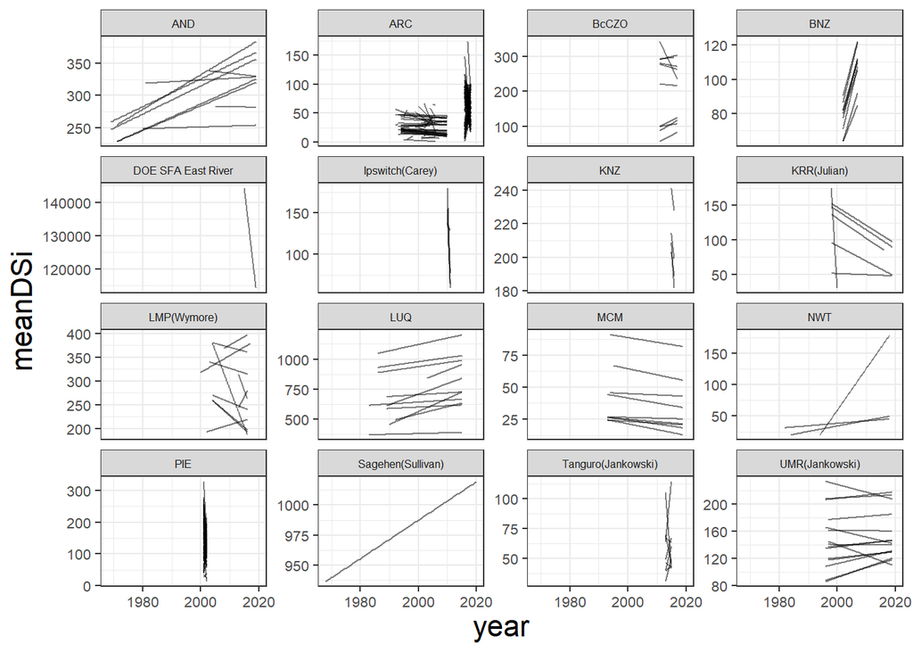

```r
ggplot(sisyn_annual, aes(year, meanDSi, group=site))+
  geom_line(stat="smooth", method="lm", se=FALSE, alpha=.5)+
  facet_wrap(~LTER, scales = "free_y")+
  scale_x_continuous(breaks=c(1980, 2000, 2020))+
  theme(strip.text.x = element_text(size = 6))
```

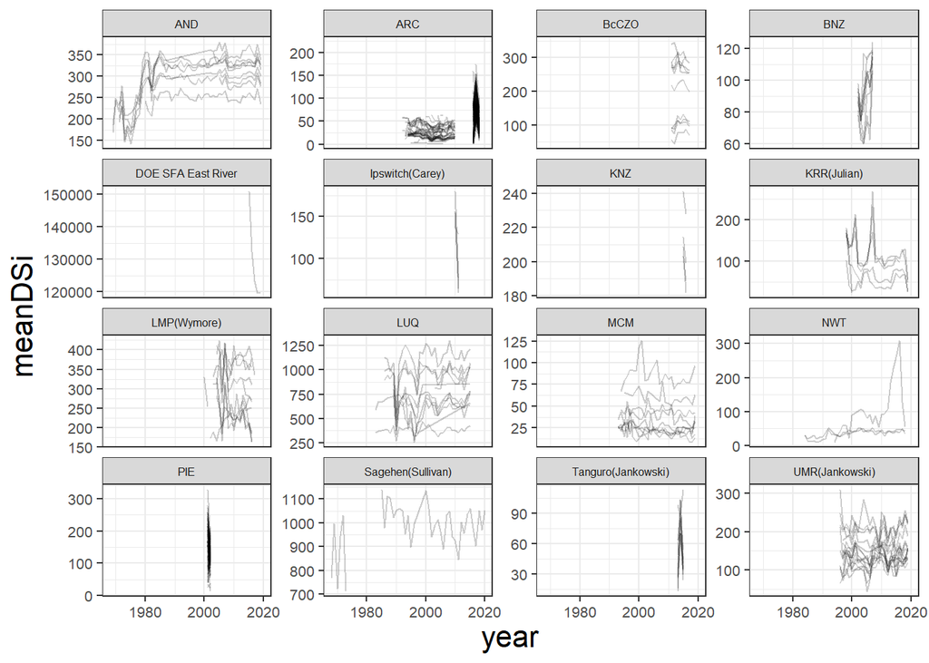

```r
ggplot(sisyn_annual, aes(year, meanDSi, group=site))+
  #geom_point(alpha=0.2)+
  geom_line(alpha=0.2)+
  facet_wrap(~LTER, scales = "free_y")+
  scale_x_continuous(breaks=c(1980, 2000, 2020))+
  theme(strip.text.x = element_text(size = 6))
```

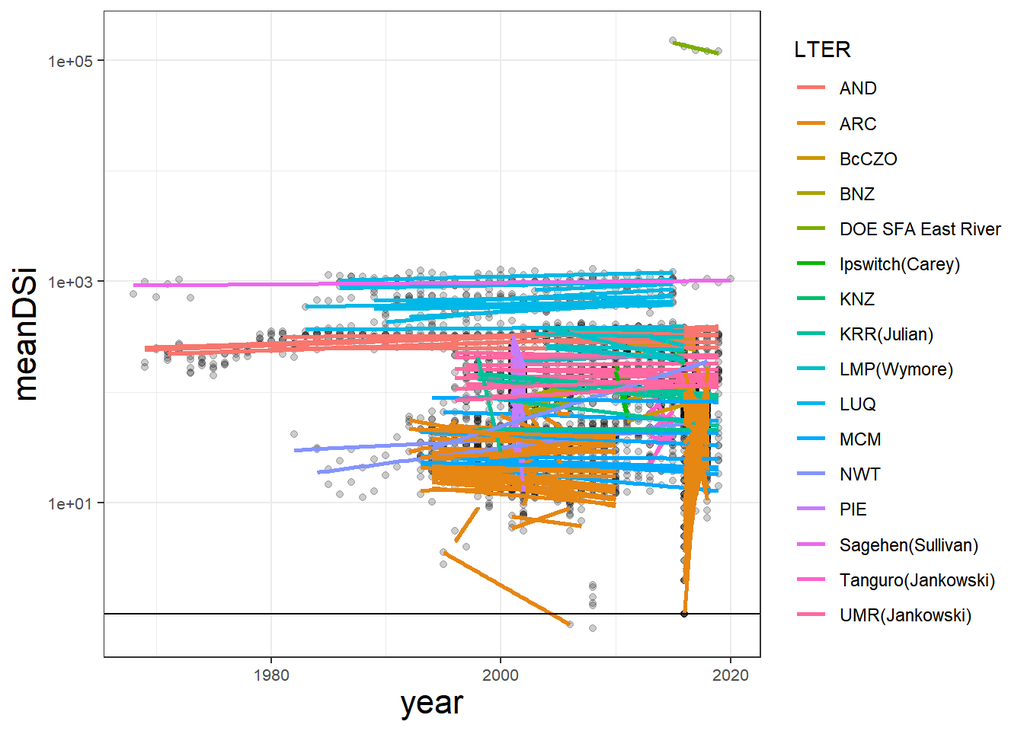

```r
ggplot(sisyn_annual, aes(year, meanDSi, group = site))+
  geom_point(alpha=0.2)+
  geom_smooth(method = 'lm', se=FALSE, aes(color = LTER))+
  scale_x_continuous(breaks=c(1980, 2000, 2020))+
  scale_y_log10()+
  theme(strip.text.x = element_text(size = 6))+
  geom_hline(yintercept = 1)
```

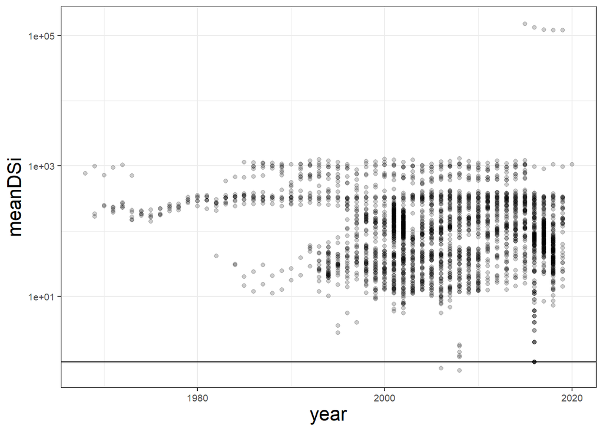

```r
ggplot(sisyn_annual, aes(year, meanDSi, group = site))+
  geom_point(alpha=0.2)+
  geom_smooth(method = 'loess', se=FALSE, aes(color = LTER))+
  scale_x_continuous(breaks=c(1980, 2000, 2020))+
  scale_y_log10()+
  theme(strip.text.x = element_text(size = 6))+
  geom_hline(yintercept = 1)
```

## 2.2 CV annual DSi

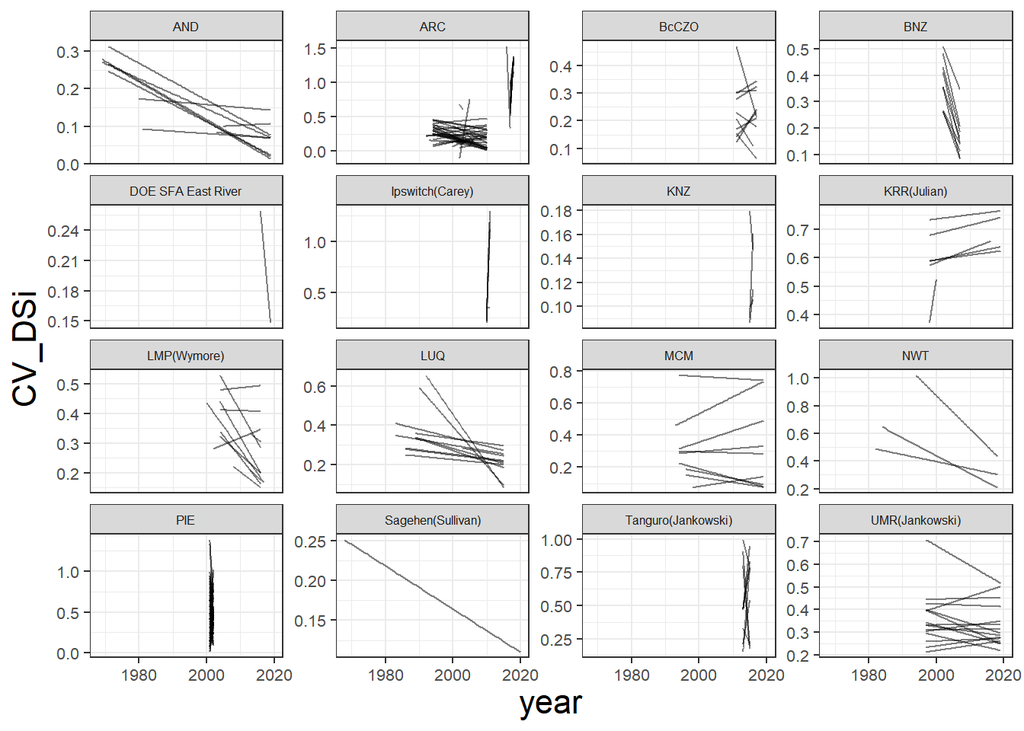

```r
ggplot(sisyn_annual, aes(year, CV_DSi, group=site))+
  geom_line(stat="smooth", method="lm", se=FALSE, alpha=.5)+
  facet_wrap(~LTER, scales = "free_y")+
  scale_x_continuous(breaks=c(1980, 2000, 2020))+
  theme(strip.text.x = element_text(size = 6))
```

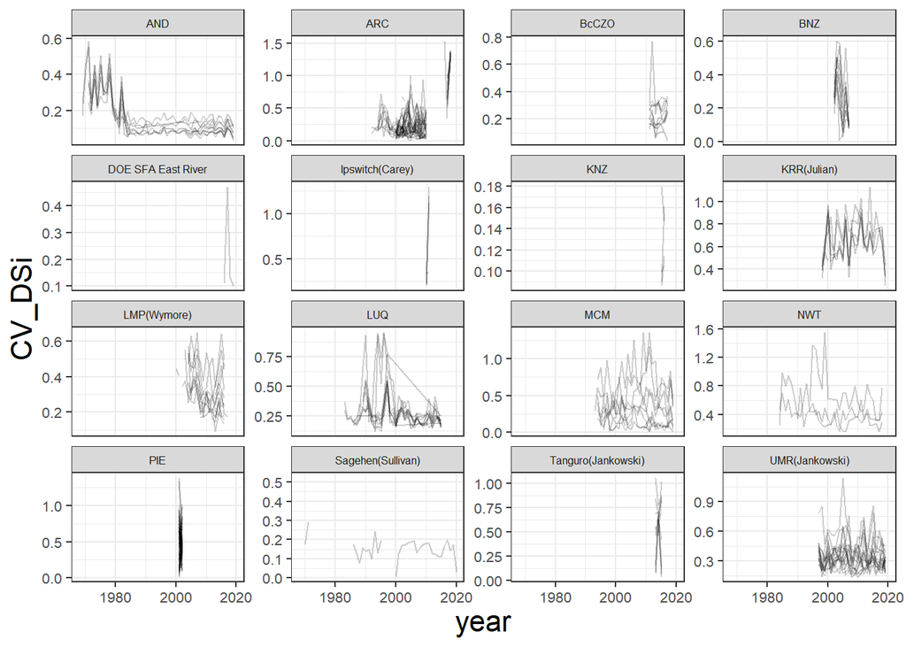

```r
ggplot(sisyn_annual, aes(year, CV_DSi, group=site))+
  #geom_point(alpha=0.2)+
  geom_line(alpha=0.2)+
  facet_wrap(~LTER, scales = "free_y")+
  scale_x_continuous(breaks=c(1980, 2000, 2020))+
  theme(strip.text.x = element_text(size = 6))
```

## 2.3 Si:N over time

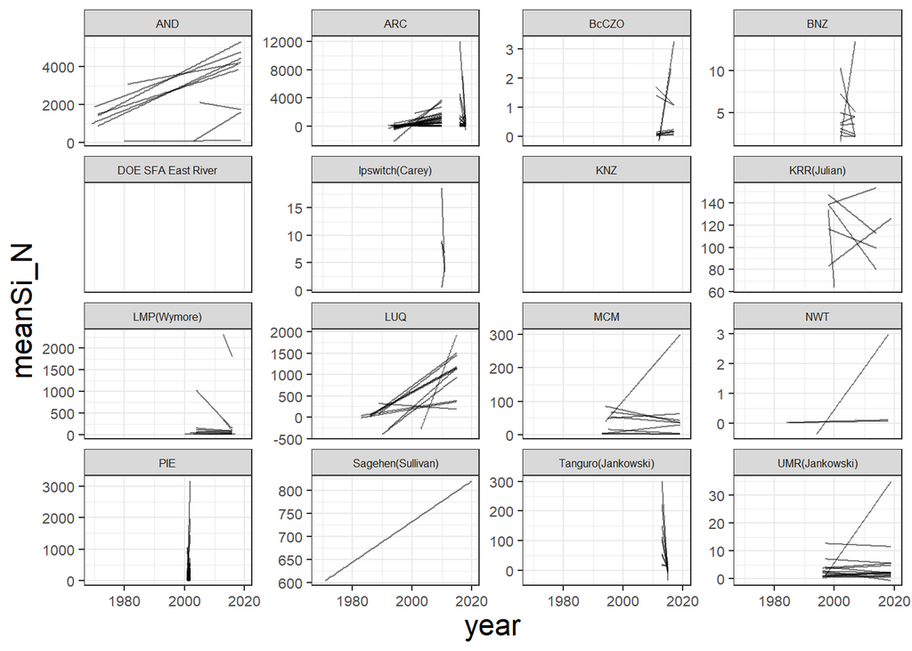

```r
ggplot(sisyn_annual, aes(year, meanSi_N, group=site))+
  geom_line(stat="smooth", method="lm", se=FALSE, alpha=.5)+
  facet_wrap(~LTER, scales = "free_y")+
  scale_x_continuous(breaks=c(1980, 2000, 2020))+
  theme(strip.text.x = element_text(size = 6))
```

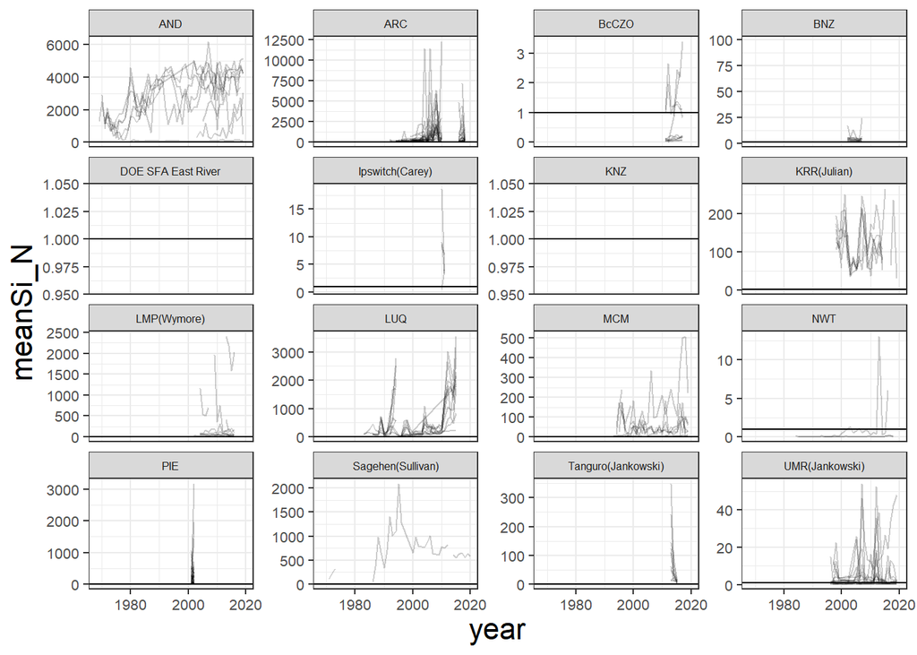

```r
ggplot(sisyn_annual, aes(year, meanSi_N, group=site))+
  #geom_point(alpha=0.2)+
  geom_line(alpha=0.2)+
  facet_wrap(~LTER, scales = "free_y")+
  scale_x_continuous(breaks=c(1980, 2000, 2020))+
  theme(strip.text.x = element_text(size = 6))+
  geom_hline(yintercept = 1)
```

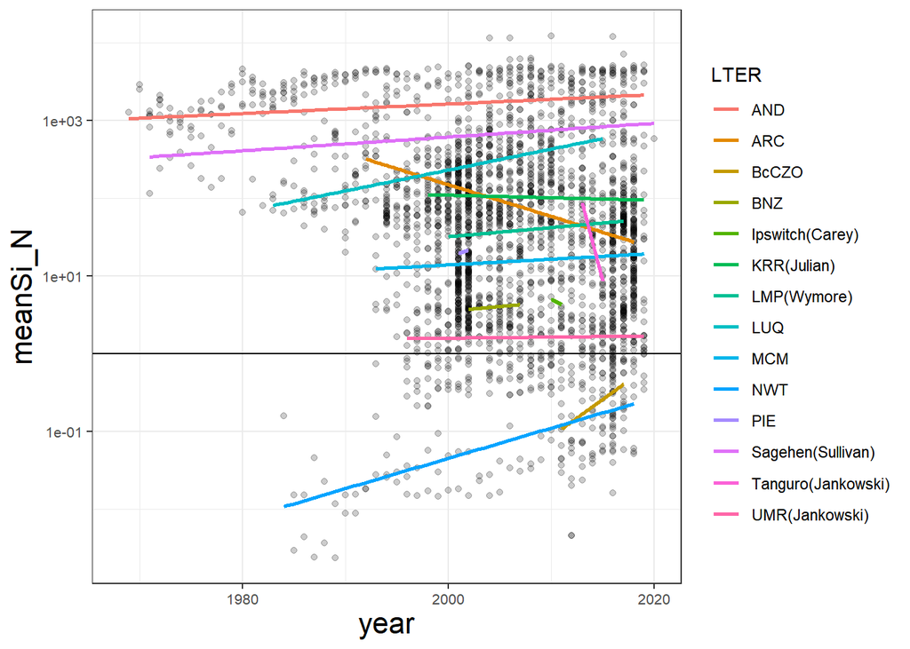

```r
ggplot(sisyn_annual, aes(year, meanSi_N, group = LTER))+
  geom_point(alpha=0.2)+
  geom_smooth(method = 'lm', se=FALSE, aes(color = LTER))+
  scale_x_continuous(breaks=c(1980, 2000, 2020))+
  scale_y_log10()+
  theme(strip.text.x = element_text(size = 6))+
  geom_hline(yintercept = 1)
```

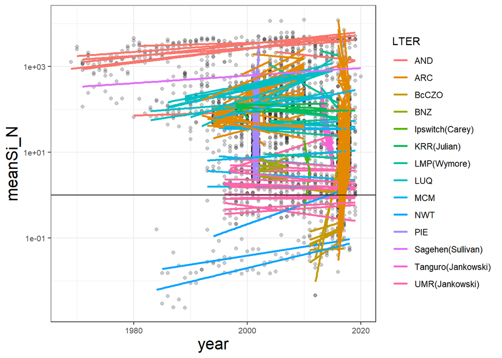

```r
ggplot(sisyn_annual, aes(year, meanSi_N, group = site))+
  geom_point(alpha=0.2)+
  geom_smooth(method = 'lm', se=FALSE, aes(color = LTER))+
  scale_x_continuous(breaks=c(1980, 2000, 2020))+
  scale_y_log10()+
  theme(strip.text.x = element_text(size = 6))+
  geom_hline(yintercept = 1)
```

## 2.4 Si:P over time

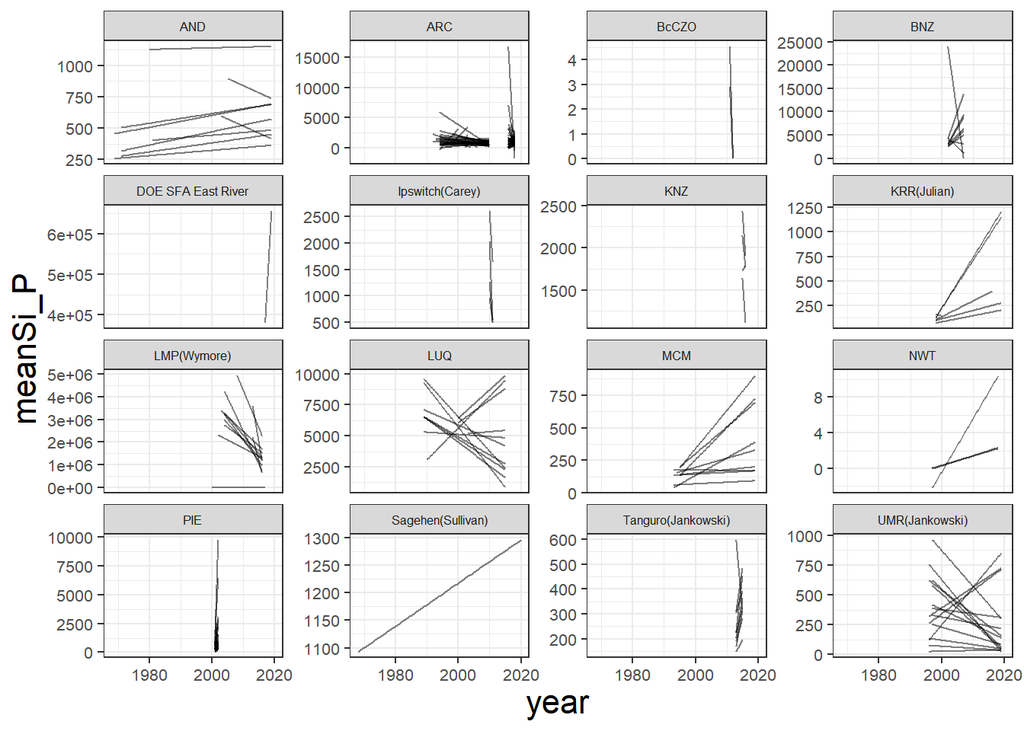

```r
ggplot(sisyn_annual, aes(year, meanSi_P, group=site))+
  geom_line(stat="smooth", method="lm", se=FALSE, alpha=.5)+
  facet_wrap(~LTER, scales = "free_y")+
  scale_x_continuous(breaks=c(1980, 2000, 2020))+
  theme(strip.text.x = element_text(size = 6))
```

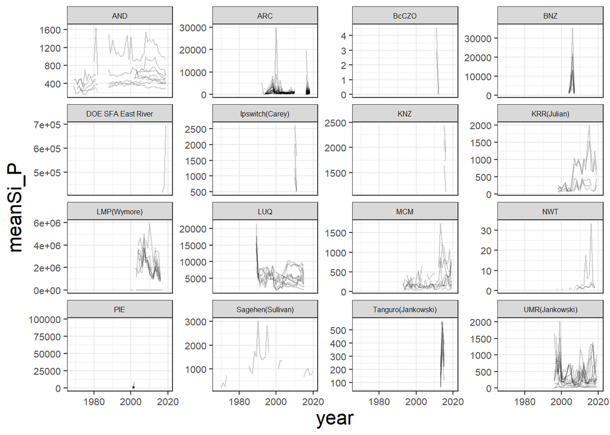

```r
ggplot(sisyn_annual, aes(year, meanSi_P, group=site))+
  #geom_point(alpha=0.2)+
  geom_line(alpha=0.2)+
  facet_wrap(~LTER, scales = "free_y")+
  scale_x_continuous(breaks=c(1980, 2000, 2020))+
  theme(strip.text.x = element_text(size = 6))
```

# 3 lapply for extracting lots of slopes

## 3.1 DSi slopes over time

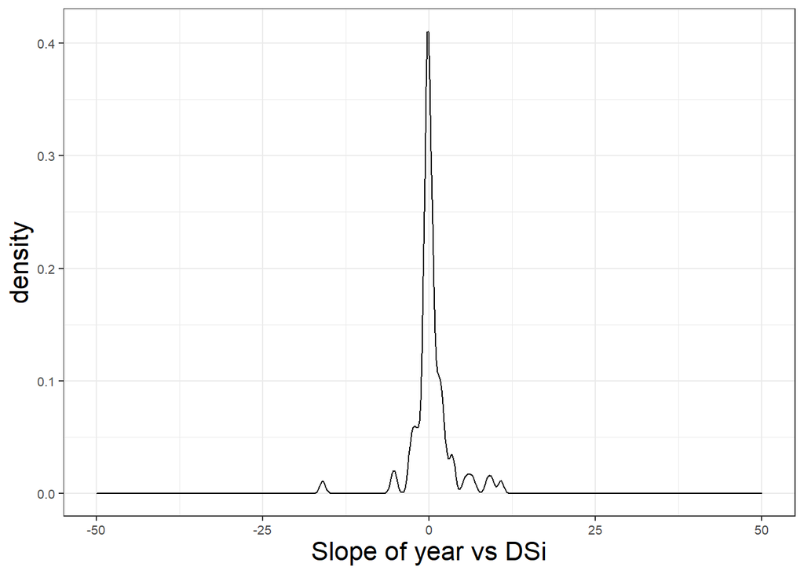

```r
#making each column contain DSi conc for each site, since this is the only way I could figure out how to do >400 regressions at once - AND selecting only long term sites

sisyn_annual_wide_Si <- sisyn_annual %>%
  filter(site %in% longtermsites) %>%        # ONLY >10 YEAR SITES!
  select(year, LTER, site, meanDSi) %>%
  filter(!is.na(meanDSi)) %>%
  pivot_wider(names_from = site, values_from = meanDSi)

#set number of columns (i.e., sites)

n <- 433


#apply a linear regression for DSi vs year for all sites. the 'as.matrix' part was necessary to make it work, but I am still not totally sure why

my_lms <- lapply(3:length(sisyn_annual_wide_Si), function(x) lm(as.matrix(sisyn_annual_wide_Si[,x]) ~ year, data=sisyn_annual_wide_Si))


#extracting the slope and intercept from my_lms and turning it into a data frame

coefs <- sapply(my_lms, coef)
coefs <- data.frame(coefs)
#rownames(coef)[1:435] <- myvars #FIGURE OUT HOW TO DO THIS!!!!

#making the coefs data more usable

coefs <- rownames_to_column(coefs)

coefs_long <- coefs %>%
  pivot_longer(!rowname,
               names_to = "coeftype",
               values_to="value")
# now we have slopes in long format and can play with those!


coefs_long %>% filter(rowname=="year") %>%
  ggplot(aes(value))+
  geom_density()+
  #scale_x_log10(labels=comma)+
  #geom_vline(xintercept = 1, linetype='dashed')+
  xlab('Slope of year vs DSi')+
  xlim(-50, 50)
```

```r
A<- coefs_long %>%
  filter(rowname=="year", value<0) %>%
  count()

B <- coefs_long %>%
  filter(rowname=="year", value>0) %>%
  count()

pct_pos <- (B/(B+A))*100

pct_pos
```

```
##          n
## 1 44.82759
```

```r
#same as above but gets list with rsquare values

summaries <- lapply(my_lms, summary)
rquares <- sapply(summaries, function(x) c(r_sq = x$r.squared,
                                adj_r_sq = x$adj.r.squared))

#same as above but gives p values

pvals <- lapply(summaries, function(x) x$coefficients[, c(1,4)])
```

## 3.2 CV of DSi slopes over time

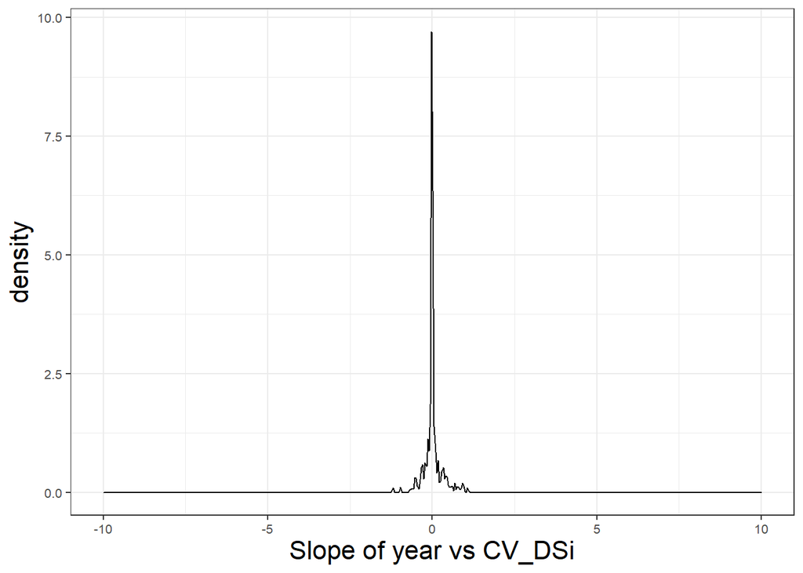

```r
#making each column contain DSi conc for each site, since this is the only way I could figure out how to do >400 regressions at once

sisyn_annual_wide_CVSi <- sisyn_annual %>%
  select(year, LTER, site, CV_DSi) %>%
  filter(!is.na(CV_DSi)) %>%
  pivot_wider(names_from = site, values_from = CV_DSi)

#set number of columns (i.e., sites)

n <- 384

#list of the columns (sites) which may or may not be useful
#myvars <- as.list(colnames(sisyn_annual_wide[3:435]))

#apply a linear regression for DSi vs year for all sites. the 'as.matrix' part was necessary to make it work, but I am still not totally sure why

my_lms <- lapply(3:n, function(x) lm(as.matrix(sisyn_annual_wide_CVSi[,x]) ~ year, data=sisyn_annual_wide_CVSi))


#extracting the slope and intercept from my_lms and turning it into a data frame

coefs <- sapply(my_lms, coef)
coefs <- data.frame(coefs)
#rownames(coef)[1:435] <- myvars #FIGURE OUT HOW TO DO THIS!!!!

#making the coefs data more usable

coefs <- rownames_to_column(coefs)

coefs_long <- coefs %>%
  pivot_longer(!rowname,
               names_to = "coeftype",
               values_to="value")
# now we have slopes in long format and can play with those!


coefs_long %>% filter(rowname=="year") %>%
  ggplot(aes(value))+
  geom_density()+
  #scale_x_log10(labels=comma)+
  #geom_vline(xintercept = 1, linetype='dashed')+
  xlab('Slope of year vs CV_DSi')+
  xlim(-10, 10)
```

```r
A<- coefs_long %>%
  filter(rowname=="year", value<0) %>%
  count()

B <- coefs_long %>%
  filter(rowname=="year", value>0) %>%
  count()

pct_pos <- (B/(B+A))*100

pct_pos
```

```
##          n
## 1 41.53226
```

> so 41.5322581 of sites have a positive slope for CV(Si) over time

## 3.3 DSi:N slopes over time

```r
#making each column contain DSi conc for each site, since this is the only way I could figure out how to do >400 regressions at once

sisyn_annual_wide_Si_N <- sisyn_annual %>%
  select(year, LTER, site, meanSi_N) %>%
  filter(!is.na(meanSi_N)) %>%
  pivot_wider(names_from = site, values_from = meanSi_N)

#set number of columns (i.e., sites)

n <- 411

#list of the columns (sites) which may or may not be useful
#myvars <- as.list(colnames(sisyn_annual_wide[3:435]))

#apply a linear regression for DSi vs year for all sites. the 'as.matrix' part was necessary to make it work, but I am still not totally sure why

my_lms <- lapply(3:n, function(x) lm(as.matrix(sisyn_annual_wide_Si_N[,x]) ~ year, data=sisyn_annual_wide_Si_N))
```

```r
#extracting the slope and intercept from my_lms and turning it into a data frame

coefs <- sapply(my_lms, coef)
coefs <- data.frame(coefs)
#rownames(coef)[1:435] <- myvars #FIGURE OUT HOW TO DO THIS!!!!

#making the coefs data more usable

coefs <- rownames_to_column(coefs)

coefs_long <- coefs %>%
  pivot_longer(!rowname,
               names_to = "coeftype",
               values_to="value")
# now we have slopes in long format and can play with those!
```

Using lapply to get regression coefficients for each site (finally)

found here https://stackoverflow.com/questions/27952653/how-to-loop-repeat-a-linear-regression-in-r

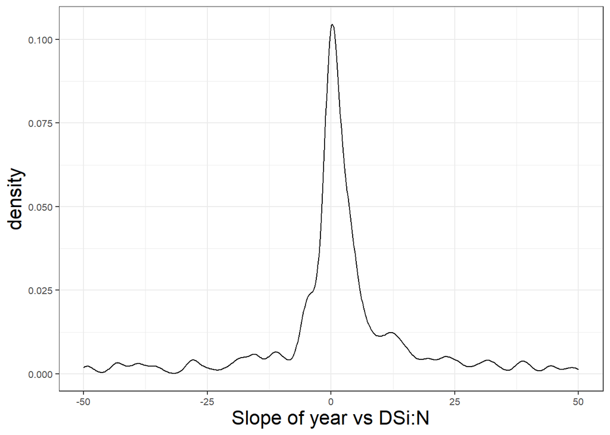

```r
coefs_long %>% filter(rowname=="year") %>%
  ggplot(aes(value))+
  geom_density()+
  #scale_x_log10(labels=comma)+
  #geom_vline(xintercept = 1, linetype='dashed')+
  xlab('Slope of year vs DSi:N')+
  xlim(-50, 50)
```

```r
coefs_long %>%
  filter(rowname=="year", value<0) %>%
  count()
```

```
## # A tibble: 1 x 1
##       n
##   <int>
## 1   139
```

# 4 Loops for extracting correlations

```r
cols <- ncol(sisyn_annual_wide_Si)-2

Correlations <- data.frame(site=character(length=cols),
                 correlation=numeric(length=cols),
                 stringsAsFactors=F)

for (i in 1:cols) {
  temp1 <- colnames(sisyn_annual_wide_Si[i+2])       # retrieves the name of predictor variable
  temp2 <- cor(sisyn_annual_wide_Si[,1], sisyn_annual_wide_Si[,i+2],
               method="pearson", #change this to spearman???
               use = "pairwise.complete.obs") # calculates the correlation between activity and predictor variable --> need to use "use"
  Correlations[i,1] <- temp1               # places the variable name into row i, column 1
  Correlations[i,2] <- temp2                # places the correlation into row i, column 2
}
```

```r
si_corr <- left_join(Correlations, si_annual_longterm)
```

> plotting correlations as effect sizes

```r
# function to give sample sizes (here, number of sites per LTER)
give.n <- function(x){
  return(c(y = mean(x), label = length(x)))
}


A <- ggplot(si_corr, aes(LTER, correlation)) +
    stat_summary(fun = mean, geom = "point") +
    stat_summary(fun.data = mean_cl_normal, geom = "pointrange", fun.args = list(mult = 1))+
  geom_hline(yintercept = 0)+
  xlab("LTER")+
  ylab("correlation of DSi ~ year")+
  stat_summary(fun.data = give.n, geom = "text", size=3, fontface="italic", position = position_nudge(x = 0.4, y=.1))+
  coord_flip()+
  scale_x_discrete(limits = rev)
A
```

[output not shown]

```r
  #stat_summary(data=grandmean, fun.data = mean, geom = "point")


#geom_polygon(aes())+

mean_corr <- mean(si_corr$correlation)

me <- qt(.975, 86)*sd(si_corr$correlation)/87

mean_cl_normal(si_corr$correlation)
```

```
##             y       ymin       ymax
## 1 -0.05232219 -0.1415401 0.03689573
```

```r
mean_corr-me
```

```
## [1] -0.06188735
```

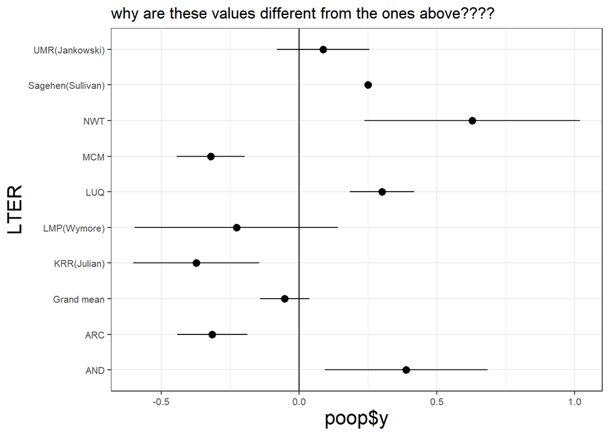

```r
meanCI <- si_corr %>%
  group_by(LTER) %>%
  summarize(poop=mean_cl_normal(correlation))

grandmean <- si_corr %>%
  summarize(poop=mean_cl_normal(correlation))
grandmean$LTER="Grand mean"

meanCI <- bind_rows(grandmean, meanCI)

ggplot(data=meanCI, mapping = aes(x=LTER, y = poop$y, ymax = poop$ymax, ymin = poop$ymin))+
  geom_pointrange()+
  coord_flip()+
  geom_hline(yintercept = 0)+
  ggtitle('why are these values different from the ones above????')
```

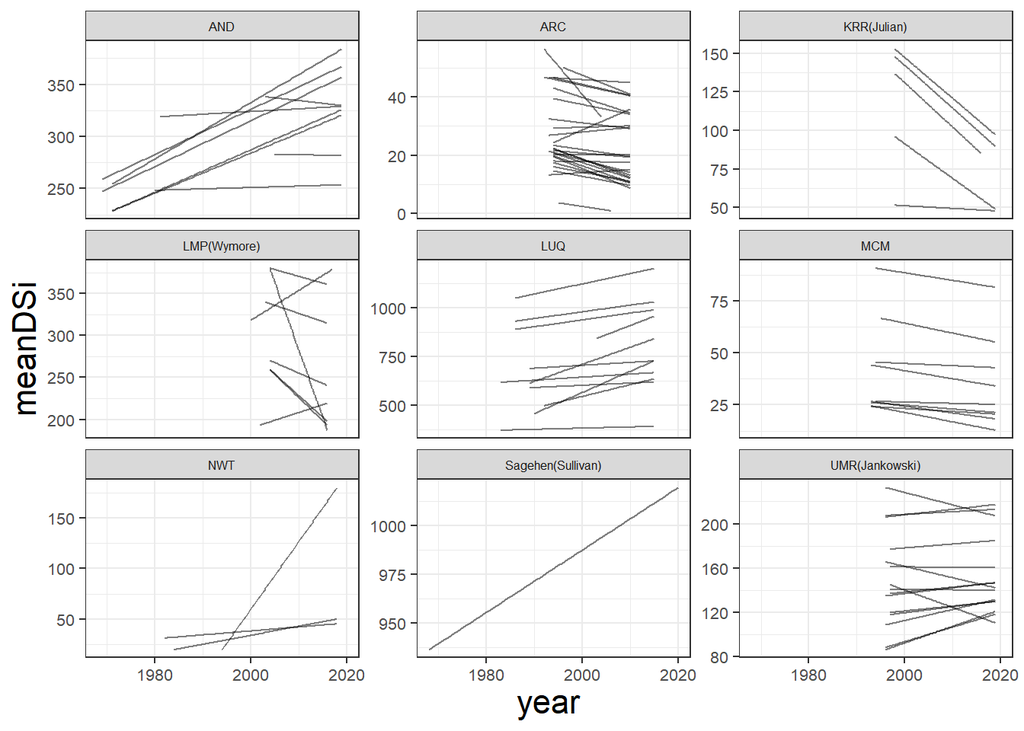

```r
B <- sisyn_annual %>% filter(site %in% longtermsites) %>%
ggplot(aes(year, meanDSi, group=site))+
  geom_line(stat="smooth", method="lm", se=FALSE, alpha=.5)+
  facet_wrap(~LTER, scales = "free_y")+
  scale_x_continuous(breaks=c(1980, 2000, 2020))+
  theme(strip.text.x = element_text(size = 6))
B
```

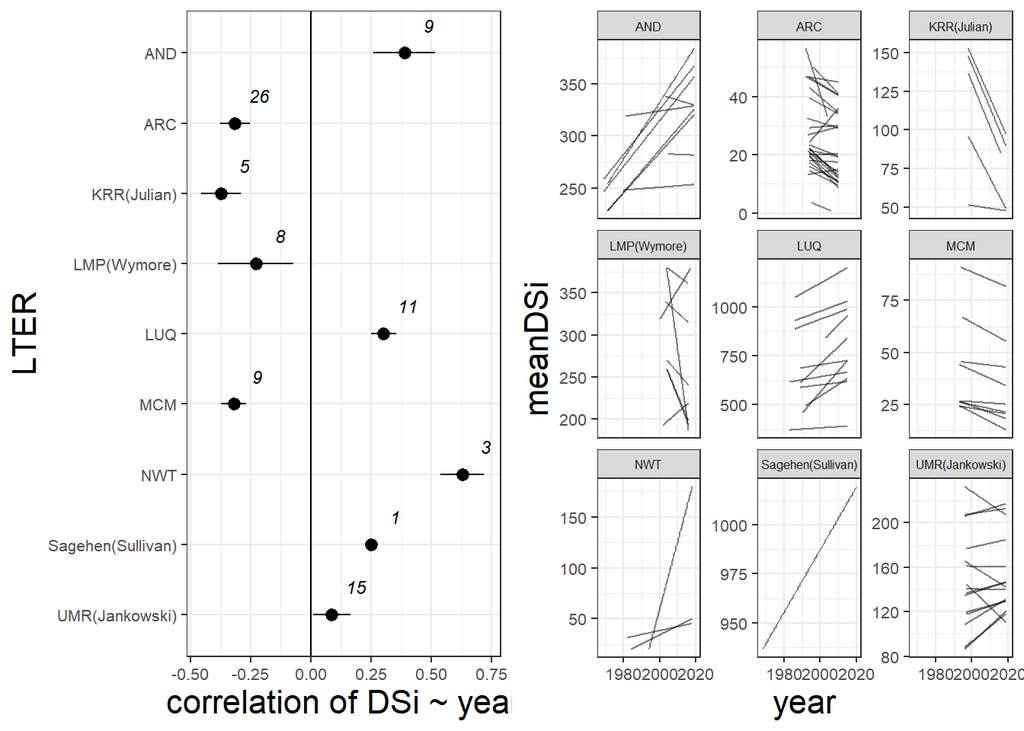

```r
ggarrange(A,B)
```

```r
A
```

[output not shown]

# 5 dplyr instead of loops

> FIX SHITTY ANDREWS DATA BEFORE 1983

```r
sisyn_annual_longterm_wide <- sisyn_annual %>%
  filter(site %in% longtermsites)


sisyn_annual_long <- sisyn_annual_longterm_wide %>%
  pivot_longer(cols = c(meanDSi:CV_PO4),
               names_to = "analyte",
               values_to = "conc")


gp <- sisyn_annual_long %>% group_by(site, LTER, analyte)
sisyn_corr_dplyr <- summarize(gp, ri=cor(year, conc, use = "pairwise.complete.obs"),
                             ni=n())
# sisyn_corr_dplyr2 <- summarize(gp, ri=cor(year, conc, use = "complete.obs"),
#                              ni=n())
#
# #there is no difference between pairwise.complete obs and complete.obs.......
# poop <- bind_cols(sisyn_corr_dplyr, sisyn_corr_dplyr2)
# ggplot(poop, aes(ri...3, ri...7))+
#   geom_point()

C <-sisyn_corr_dplyr %>%
  filter(analyte =="meanDSi") %>%
  ggplot(aes(LTER, ri)) +
    stat_summary(fun = mean, geom = "point") +
    stat_summary(fun.data = mean_cl_normal, geom = "pointrange", fun.args = list(mult = 1))+
  geom_hline(yintercept = 0)+
  xlab("LTER")+
  ylab("correlation of DSi ~ year")+
  stat_summary(fun.data = give.n, geom = "text", size=3, fontface="italic", position = position_nudge(x = 0.4, y=.1))+
  coord_flip()+
  scale_x_discrete(limits = rev)
C
```

[output not shown]

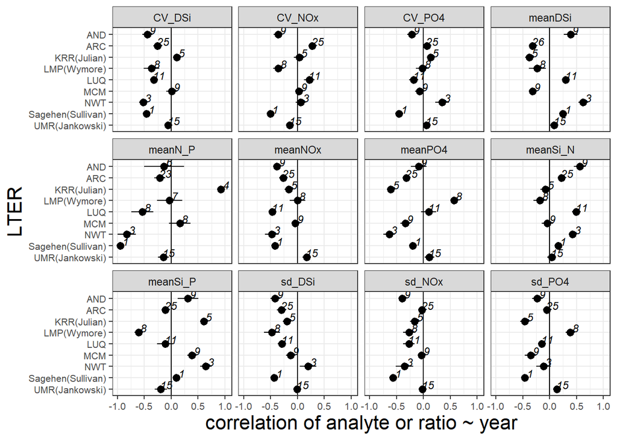

```r
ggplot(sisyn_corr_dplyr, aes(LTER, ri)) +
    stat_summary(fun = mean, geom = "point") +
    stat_summary(fun.data = mean_cl_normal, geom = "pointrange", fun.args = list(mult = 1))+
  geom_hline(yintercept = 0)+
  xlab("LTER")+
  ylab("correlation of analyte or ratio ~ year")+
  stat_summary(fun.data = give.n, geom = "text", size=3, fontface="italic", position = position_nudge(x = 0.4, y=.1))+
  coord_flip()+
  scale_x_discrete(limits = rev)+
  facet_wrap(~analyte)
```

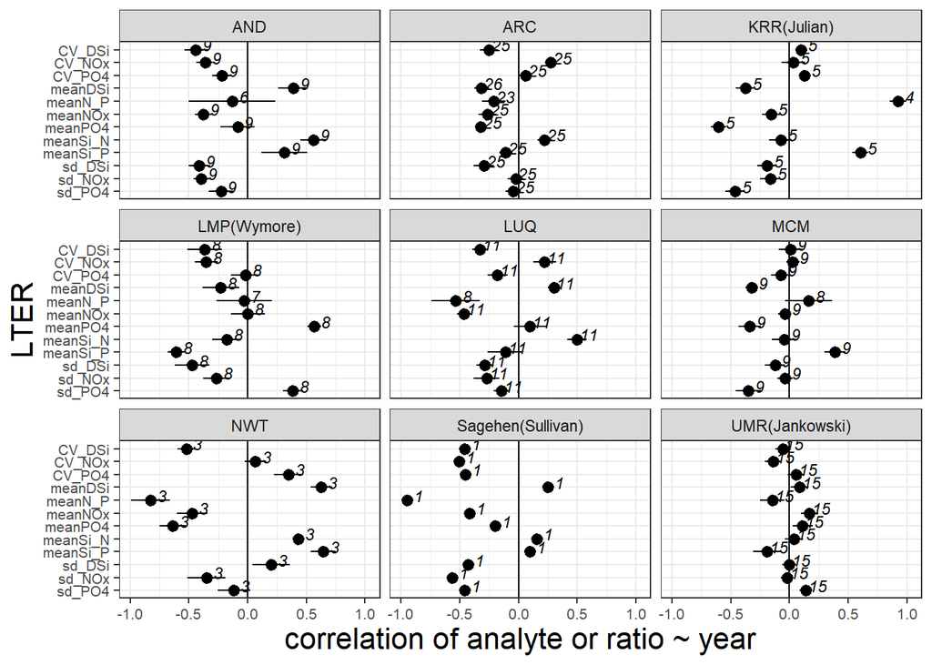

```r
ggplot(sisyn_corr_dplyr, aes(analyte, ri)) +
    stat_summary(fun = mean, geom = "point") +
    stat_summary(fun.data = mean_cl_normal, geom = "pointrange", fun.args = list(mult = 1))+
  geom_hline(yintercept = 0)+
  xlab("LTER")+
  ylab("correlation of analyte or ratio ~ year")+
  stat_summary(fun.data = give.n, geom = "text", size=3, fontface="italic", position = position_nudge(x = 0.4, y=.1))+
  coord_flip()+
  scale_x_discrete(limits = rev)+
  facet_wrap(~LTER)
```

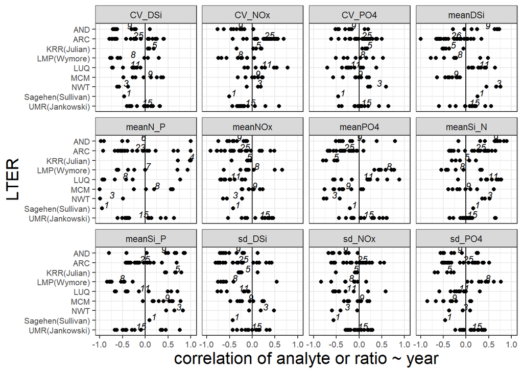

```r
ggplot(sisyn_corr_dplyr, aes(LTER, ri)) +
  geom_point()+
  geom_hline(yintercept = 0)+
  xlab("LTER")+
  ylab("correlation of analyte or ratio ~ year")+
  stat_summary(fun.data = give.n, geom = "text", size=3, fontface="italic", position = position_nudge(x = 0.4, y=.1))+
  coord_flip()+
  scale_x_discrete(limits = rev)+
  facet_wrap(~analyte)
```

> Also checking the approaches here for using lms and also the suggestion for how to use nlme to deal with autocorrelation

https://stackoverflow.com/questions/1169539/linear-regression-and-group-by-in-r

> also here with updated info on using broom since they screwed that up recently

https://stackoverflow.com/questions/22713325/fitting-several-regression-models-with-dplyr

> and this seems to work, although some slope are totally nuts:

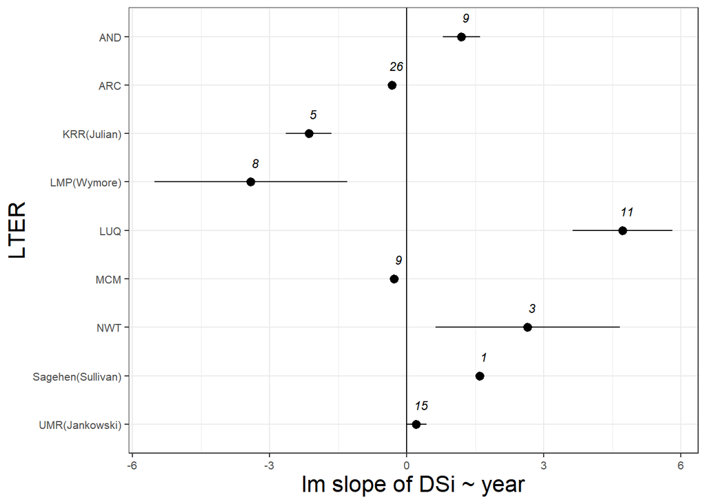

```r
fitted_models <-  sisyn_annual_long %>%
  filter(!is.na(conc)) %>%
  group_by(site, LTER, analyte) %>%
  do(model = tidy(lm(conc ~ year, data = .))) %>% # only works if you include the broom::tidy in here
  unnest(model)

# lm slopes for just DSi

D <- fitted_models %>%
  filter(term=="year", analyte == "meanDSi") %>%
  ggplot(aes(LTER, estimate)) +
    stat_summary(fun = mean, geom = "point") +
    stat_summary(fun.data = mean_cl_normal, geom = "pointrange", fun.args = list(mult = 1))+
  geom_hline(yintercept = 0)+
  xlab("LTER")+
  ylab("lm slope of DSi ~ year")+
  stat_summary(fun.data = give.n, geom = "text", size=3, fontface="italic", position = position_nudge(x = 0.4, y=.1))+
  coord_flip()+
  scale_x_discrete(limits = rev)
D
```

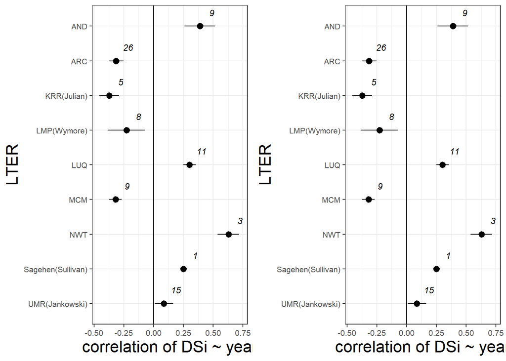

```r
# compare correlations
ggarrange(A, C)
```

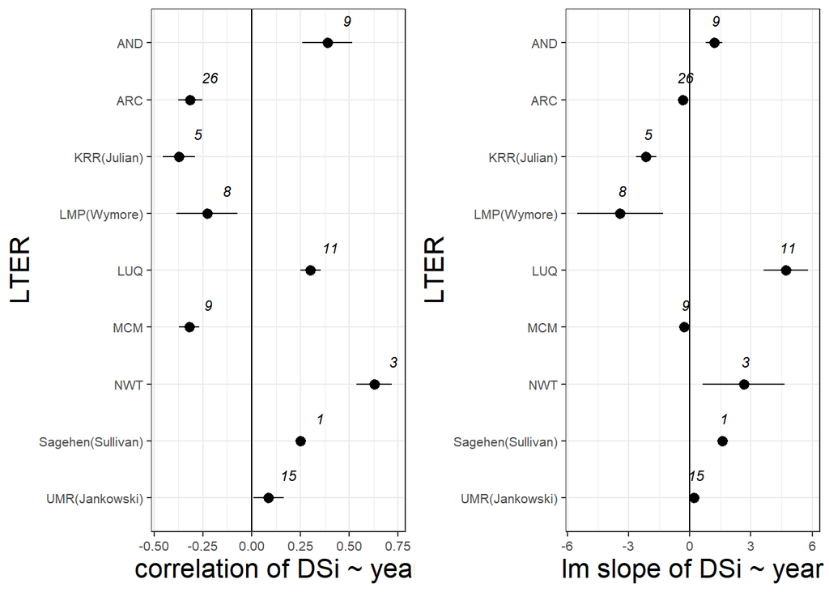

```r
ggarrange(C,D)
```

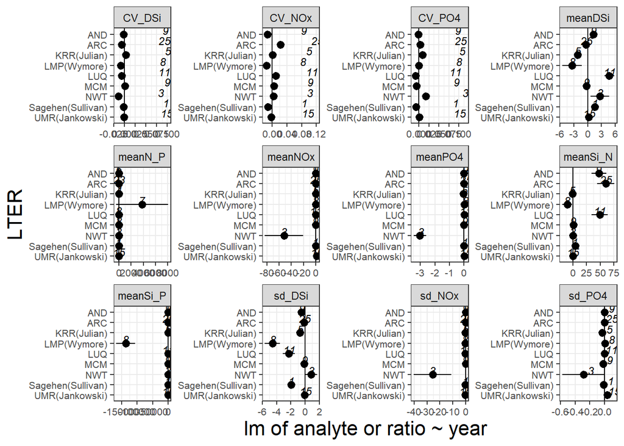

```r
fitted_models %>%
  filter(term=="year") %>%
  ggplot(aes(LTER, estimate)) +
    stat_summary(fun = mean, geom = "point") +
    stat_summary(fun.data = mean_cl_normal, geom = "pointrange", fun.args = list(mult = 1))+
  geom_hline(yintercept = 0)+
  xlab("LTER")+
  ylab("lm of analyte or ratio ~ year")+
  stat_summary(fun.data = give.n, geom = "text", size=3, fontface="italic", position = position_nudge(x = 0.4, y=.1))+
  coord_flip()+
  scale_x_discrete(limits = rev)+
  facet_wrap(~analyte, scales = 'free')
```

> nlme thing needs work, but maybe add autocorrelation to above iteration?

# 6 TO DO

- check Dornelas 2014 methods for slope of diversity over time for many sites
- plot slopes by biome in forest plots
- meta-regression for what would explain slopes (latitude, land cover, etc)

```r
knitr::knit_exit()
```